# COM747 Week 10: Data Analytics, Data Engineering and Black-Box Methods

Lecture demonstrations and complete seminar solutions

> **How to use this notebook.** The guest lecture showed an investigative analyst’s process (load → validate → transform → present) on a fraud case. Part A rebuilds that process in R on **made-up** data, including real SQL run against an in-memory database, so you can see the R and SQL side by side. Part B completes seminar Exercise 1 (strengths and weaknesses of supervised methods) and Part C completes Exercise 2 (neural networks and SVMs, “black box” methods). No data files are needed.

```r
library(DBI); library(RSQLite)     # SQL inside R
library(dplyr)                      # joins and summaries, tidyverse style
library(neuralnet)                  # install.packages("neuralnet")
library(e1071)                      # svm()
library(class); library(rpart)      # knn(), decision trees for comparison
```

# Part A: The analyst’s process in R

## A1. Simulate the client’s data

Three tables, as in the case: log books (scanned, with messy names), employee details, and diesel claims. One driver (Murphy) claims diesel on some days with no trip.

```r
set.seed(2024)
drivers <- c("Byrne", "Doyle", "Kelly", "Murphy", "Nolan", "Walsh")
days <- seq(as.Date("2024-01-01"), as.Date("2024-03-31"), by = "day")
workdays <- days[!weekdays(days) %in% c("Saturday", "Sunday")]

log_books <- do.call(rbind, lapply(drivers, function(d) {
  worked <- sort(sample(workdays, 50))
  data.frame(scanned_name = d, date = worked, duration = round(runif(50, 6, 10.5), 1))
}))
# scanning makes names messy: random case and stray spaces
messy <- sample(nrow(log_books), 60)
log_books$scanned_name[messy] <- toupper(log_books$scanned_name[messy])
log_books$scanned_name[messy[1:20]] <- paste0(" ", log_books$scanned_name[messy[1:20]], " ")

# diesel claims: about 12 litres per hour driven, priced per litre
diesel_claims <- transform(log_books, driver = trimws(tools::toTitleCase(tolower(scanned_name))),
                           litres = round(duration * rnorm(nrow(log_books), 12, 0.8)))[, c("driver", "date", "litres")]
# Murphy's extra claims on weekends (no log book trip)
weekend <- days[weekdays(days) == "Saturday"]
extra <- data.frame(driver = "Murphy", date = sample(weekend, 10), litres = round(runif(10, 70, 110)))
diesel_claims <- rbind(diesel_claims, extra)
diesel_claims$amount <- round(diesel_claims$litres * 1.68, 2)     # € per litre

employees <- data.frame(driver = drivers, depot = c("Cork", "Cork", "Dublin", "Dublin", "Galway", "Galway"),
                        truck_age = c(3, 7, 2, 4, 6, 5))
head(log_books); head(diesel_claims); employees
```

```
##   scanned_name       date duration
## 1        Byrne 2024-01-01      6.9
## 2        Byrne 2024-01-02      8.8
## 3        Byrne 2024-01-03      8.0
## 4        Byrne 2024-01-04      7.4
## 5        Byrne 2024-01-08      9.2
## 6       BYRNE  2024-01-09      7.3
```

```
##   driver       date litres amount
## 1  Byrne 2024-01-01     83 139.44
## 2  Byrne 2024-01-02    103 173.04
## 3  Byrne 2024-01-03     96 161.28
## 4  Byrne 2024-01-04     85 142.80
## 5  Byrne 2024-01-08    106 178.08
## 6  Byrne 2024-01-09     83 139.44
```

```
##   driver  depot truck_age
## 1  Byrne   Cork         3
## 2  Doyle   Cork         7
## 3  Kelly Dublin         2
## 4 Murphy Dublin         4
## 5  Nolan Galway         6
## 6  Walsh Galway         5
```

## A2. Load into a database

```r
con <- dbConnect(RSQLite::SQLite(), ":memory:")      # a throwaway SQL database in memory
dbWriteTable(con, "log_books_table", transform(log_books, date = as.character(date)))
dbWriteTable(con, "diesel_claims_table", transform(diesel_claims, date = as.character(date)))
dbWriteTable(con, "employees", employees)
dbListTables(con)
```

```
## [1] "diesel_claims_table" "employees"           "log_books_table"
```

## A3. Validate: data sent = data loaded

```r
fingerprint <- function(df) {
  num <- df[sapply(df, is.numeric)]
  list(cols = ncol(df), rows = nrow(df),
       stats = sapply(num, function(x) c(min = min(x), max = max(x), sum = sum(x))))
}
sent   <- fingerprint(diesel_claims)
loaded <- fingerprint(dbGetQuery(con, "SELECT * FROM diesel_claims_table"))
c(sent = sent$cols, loaded = loaded$cols)
```

```
##   sent loaded
##      4      4
```

```r
c(sent = sent$rows, loaded = loaded$rows)
```

```
##   sent loaded
##    310    310
```

```r
all.equal(sent$stats, loaded$stats)
```

```
## [1] TRUE
```

```r
# The same checks in SQL
dbGetQuery(con, "SELECT COUNT(*) AS n_rows, MIN(amount) AS min_amt, MAX(amount) AS max_amt, SUM(amount) AS sum_amt
                 FROM diesel_claims_table")
```

```
##   n_rows min_amt max_amt  sum_amt
## 1    310  105.84  233.52 51779.28
```

What a broken load looks like (the file lost its last 12 rows and amounts were stored as integers):

```r
broken <- head(diesel_claims, -12)
broken$amount <- floor(broken$amount)
b <- fingerprint(broken)
c(sent = sent$rows, loaded = b$rows)
```

```
##   sent loaded
##    310    298
```

```r
round(sent$stats[, "amount"] - b$stats[, "amount"], 2)    # every amount check differs
```

```
##     min     max     sum
##    0.84    0.52 1979.28
```

## A4. Transform: cleanse the names

```r
table(log_books$scanned_name)[1:8]            # " MURPHY ", "MURPHY", "Murphy" are one person
```

```
##
##   BYRNE    DOYLE    KELLY   MURPHY    NOLAN    WALSH     BYRNE    Byrne
##        2        2        2        5        4        5        8       40
```

```r
log_books$cleansed_name <- trimws(tools::toTitleCase(tolower(log_books$scanned_name)))
table(log_books$cleansed_name)
```

```
##
##  Byrne  Doyle  Kelly Murphy  Nolan  Walsh
##     50     50     50     50     50     50
```

```r
dbWriteTable(con, "log_books_table", transform(log_books, date = as.character(date)), overwrite = TRUE)
```

## A5. Transform: join (SQL and R)

The lecture’s query:

```r
joined_sql <- dbGetQuery(con, "
  SELECT lb.cleansed_name, lb.date, lb.duration, dc.litres, dc.amount
  FROM log_books_table lb
  JOIN diesel_claims_table dc ON lb.cleansed_name = dc.driver AND lb.date = dc.date")
nrow(joined_sql); head(joined_sql)
```

```
## [1] 300
```

```
##   cleansed_name       date duration litres amount
## 1         Byrne 2024-01-01      6.9     83 139.44
## 2         Byrne 2024-01-02      8.8    103 173.04
## 3         Byrne 2024-01-03      8.0     96 161.28
## 4         Byrne 2024-01-04      7.4     85 142.80
## 5         Byrne 2024-01-08      9.2    106 178.08
## 6         Byrne 2024-01-09      7.3     83 139.44
```

The same in base R and dplyr:

```r
joined_base <- merge(log_books, diesel_claims,
                     by.x = c("cleansed_name", "date"), by.y = c("driver", "date"))   # inner join
joined_dplyr <- inner_join(log_books, diesel_claims, by = c(cleansed_name = "driver", "date"))
c(sql = nrow(joined_sql), base = nrow(joined_base), dplyr = nrow(joined_dplyr))
```

```
##   sql  base dplyr
##   300   300   300
```

The inner join silently drops claims with no matching trip, which are exactly the ones we care about. An **anti-join** finds them:

```r
no_trip_sql <- dbGetQuery(con, "
  SELECT dc.* FROM diesel_claims_table dc
  LEFT JOIN log_books_table lb ON lb.cleansed_name = dc.driver AND lb.date = dc.date
  WHERE lb.cleansed_name IS NULL")
no_trip <- anti_join(diesel_claims, log_books, by = c(driver = "cleansed_name", "date"))
nrow(no_trip_sql); nrow(no_trip)
```

```
## [1] 10
```

```
## [1] 10
```

```r
table(no_trip$driver)
```

```
##
## Murphy
##     10
```

```r
no_trip %>% mutate(day = weekdays(date)) %>% count(driver, day)
```

```
##   driver      day  n
## 1 Murphy Saturday 10
```

**Ask:** Which join type would you have used first, and what would you have missed? Inner joins are the default in SQL; always count what *didn’t* match.

## A6. Present: aggregate and visualise

```r
per_driver <- diesel_claims %>% group_by(driver) %>% summarise(litres = sum(litres), claims = n(), euro = sum(amount)) %>%
  left_join(log_books %>% group_by(cleansed_name) %>% summarise(hours = sum(duration)), by = c(driver = "cleansed_name")) %>%
  left_join(employees, by = "driver") %>%
  mutate(litres_per_hour = round(litres / hours, 1))
per_driver
```

```
## # A tibble: 6 x 8
##   driver litres claims   euro hours depot  truck_age litres_per_hour
##   <chr>   <dbl>  <int>  <dbl> <dbl> <chr>      <dbl>           <dbl>
## 1 Byrne    4867     50  8177.  406. Cork           3            12
## 2 Doyle    4901     50  8234.  409. Cork           7            12
## 3 Kelly    5160     50  8669.  428. Dublin         2            12
## 4 Murphy   5996     60 10073.  419  Dublin         4            14.3
## 5 Nolan    5127     50  8613.  426. Galway         6            12
## 6 Walsh    4770     50  8014.  403. Galway         5            11.8
```

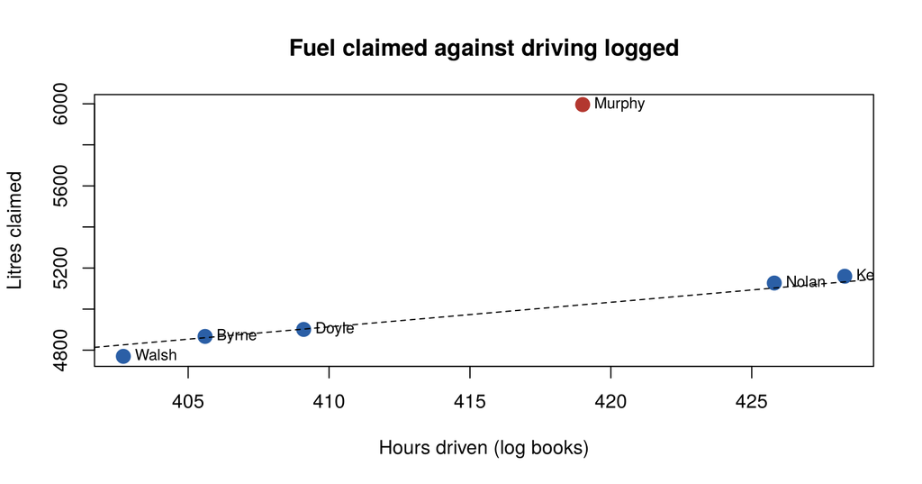

```r
fleet_rate <- with(subset(per_driver, driver != "Murphy"), sum(litres) / sum(hours))
plot(litres ~ hours, data = per_driver, pch = 19, cex = 1.6,
     col = ifelse(per_driver$driver == "Murphy", "#b3372f", "#2b5fa6"),
     xlab = "Hours driven (log books)", ylab = "Litres claimed", main = "Fuel claimed against driving logged")
abline(0, fleet_rate, lty = 2)
text(per_driver$hours, per_driver$litres, per_driver$driver, pos = 4, cex = 0.8)
```

**Evidence, not proof.** Murphy’s ratio is well above the fleet’s, and the anti-join shows the extra claims fall on Saturdays. Before presenting, check alternative explanations (an older truck? missing log-book scans?) and say what the data can and can’t show. Here `truck_age` is 4 for Murphy, so age doesn’t explain it.

```r
dbDisconnect(con)
```

## A7. The data engineer’s version: a repeatable pipeline

An engineer would wrap the same steps in functions so the pipeline can run every time a new file lands, and stop if a check fails.

```r
extract   <- function(path) read.csv(path, stringsAsFactors = FALSE)
validate  <- function(df, expected_rows, expected_cols) {
  if (nrow(df) != expected_rows) stop("Row count ", nrow(df), " != ", expected_rows)
  if (ncol(df) != expected_cols) stop("Column count ", ncol(df), " != ", expected_cols)
  invisible(df)
}
transform_claims <- function(df) df %>% mutate(date = as.Date(date)) %>% group_by(driver) %>% summarise(litres = sum(litres))
load_to_db <- function(df, con, name) { dbWriteTable(con, name, df, overwrite = TRUE); invisible(TRUE) }

# simulate a delivery arriving in the landing zone
landing <- tempfile(fileext = ".csv"); write.csv(diesel_claims, landing, row.names = FALSE)
con <- dbConnect(RSQLite::SQLite(), ":memory:")
extract(landing) |> validate(expected_rows = nrow(diesel_claims), expected_cols = 4) |>
  transform_claims() |> load_to_db(con, "claims_by_driver")
dbGetQuery(con, "SELECT * FROM claims_by_driver ORDER BY litres DESC")
```

```
##   driver litres
## 1 Murphy   5996
## 2  Kelly   5160
## 3  Nolan   5127
## 4  Doyle   4901
## 5  Byrne   4867
## 6  Walsh   4770
```

```r
# a bad delivery is stopped at validation, so nothing downstream runs
try(extract(landing) |> head(-5) |> validate(expected_rows = nrow(diesel_claims), expected_cols = 4))
```

```
## Error in validate(head(extract(landing), -5), expected_rows = nrow(diesel_claims),  :
##   Row count 305 != 310
```

```r
dbDisconnect(con)
```

# Part B: Exercise 1, strengths and weaknesses

Completed from Lantz, *Machine Learning with R*, with an example of when you would and would not use each method.

| Method | Strengths | Weaknesses | Use it for… | Avoid it for… |
| --- | --- | --- | --- | --- |
| **Decision trees** | Easy to explain as a flowchart; handles numeric and categorical data and missing values; selects important features; fast | Unstable (small data changes alter the tree); overfits unless pruned; axis-parallel splits; biased towards features with many levels | Credit or triage decisions that must be explained | Very noisy data (use a random forest instead) |
| **k-nearest neighbour** | Simple; no training; no assumptions about the distribution | Choice of k; needs scaling; slow predictions on large data; no model to interpret; sensitive to irrelevant features and missing data | Small, low-dimensional data; similarity-based recommendations | Millions of rows needing real-time predictions |
| **Neural networks** | Model almost any non-linear pattern; excellent on images, signals, speech, text | Black box; needs lots of data and compute; many hyperparameters; overfits; needs scaled inputs | ECG classification from a million labelled recordings | Small tabular data where reasons are required |
| **Support vector machines** | Accurate; robust to noise; good with many features (text, genes) | Black box; kernel and parameter tuning by trial and error; slow on huge data; no probabilities by default | Text and gene-expression classification | When explanation or calibrated probabilities are needed |
| **Multiple regression** | Interpretable coefficients with p-values and confidence intervals; widely understood | Assumes linearity and well-behaved residuals; sensitive to outliers; you must specify the form | Estimating how a price depends on several factors | Strongly non-linear or interacting relationships |
| **Logistic regression** | Probabilities and odds ratios; fast; strong baseline for binary outcomes | Linear in the log-odds; struggles with separation and heavy imbalance | Predicting survival or default with an explanation | Images, complex interactions |
| **Naive Bayes** | Fast, simple; robust to noise and missing data; good with many features and little data | Assumes independent, equally important features; probabilities poorly calibrated; numeric features need care | Spam filtering and text classification | When features are strongly dependent and probabilities matter |

**Discuss:** Which of these are “white box” (you can read the reasoning) and which are “black box”? Trees, regression, logistic regression and Naive Bayes are white box; k-NN is transparent per prediction but has no model; neural networks and SVMs are black box.

# Part C: Exercise 2, black-box methods

## C1. The sheet’s network

```r
set.seed(1)
IrisDF <- iris
IrisDF$Species <- factor(IrisDF$Species)
model <- neuralnet(Species ~ Petal.Length + Petal.Width + Sepal.Width + Sepal.Length,
                   IrisDF, linear.output = FALSE)
# linear.output = FALSE: apply the logistic activation to the outputs too (classification)
model$result.matrix[1:3, ]      # error, threshold reached, steps
```

```
##             error reached.threshold             steps
##      25.012203025       0.009497745      88.000000000
```

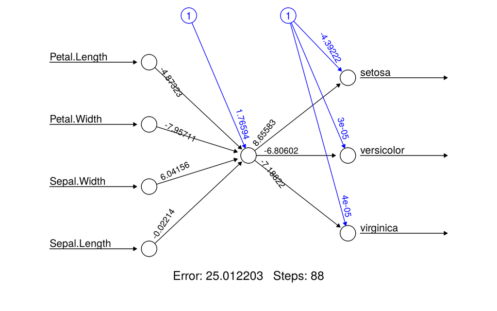

```r
plot(model, rep = "best")       # rep = "best" draws it inside the notebook rather than a new window
```

The default is **one** hidden neuron. How good is it, even on the data it was trained on?

```r
p <- predict(model, IrisDF)           # one column of scores per species
head(round(p, 3))
```

```
##       [,1]  [,2]  [,3]
## [1,] 0.986 0.001 0.001
## [2,] 0.986 0.001 0.001
## [3,] 0.986 0.001 0.001
## [4,] 0.986 0.001 0.001
## [5,] 0.986 0.001 0.001
## [6,] 0.986 0.001 0.001
```

```r
pred <- levels(IrisDF$Species)[max.col(p)]
table(predicted = pred, actual = IrisDF$Species)
```

```
##             actual
## predicted    setosa versicolor virginica
##   setosa         50          0         0
##   versicolor      0         25        24
##   virginica       0         25        26
```

```r
mean(pred == IrisDF$Species)
```

```
## [1] 0.6733333
```

**Only about 67% on its own training data.** Setosa is perfect, but versicolor and virginica get almost identical output weights, so the network can’t tell them apart. With one hidden neuron every flower is reduced to a single number, and the unscaled inputs make training harder. “There is no testing here” too. The fixes are below.

## C2. Scale, split and use more hidden neurons

```r
sc <- IrisDF
sc[, 1:4] <- scale(sc[, 1:4])                 # neural networks need inputs on similar scales
set.seed(1)
idx   <- sample(nrow(sc), 105)                # 70% train, 30% test
train <- sc[idx, ]; test <- sc[-idx, ]

set.seed(1)
nn3 <- neuralnet(Species ~ ., data = train, hidden = 3, linear.output = FALSE)
pred3 <- levels(sc$Species)[max.col(predict(nn3, test))]
table(predicted = pred3, actual = test$Species)
```

```
##             actual
## predicted    setosa versicolor virginica
##   setosa         15          0         0
##   versicolor      0         17         2
##   virginica       0          0        11
```

```r
mean(pred3 == test$Species)
```

```
## [1] 0.9555556
```

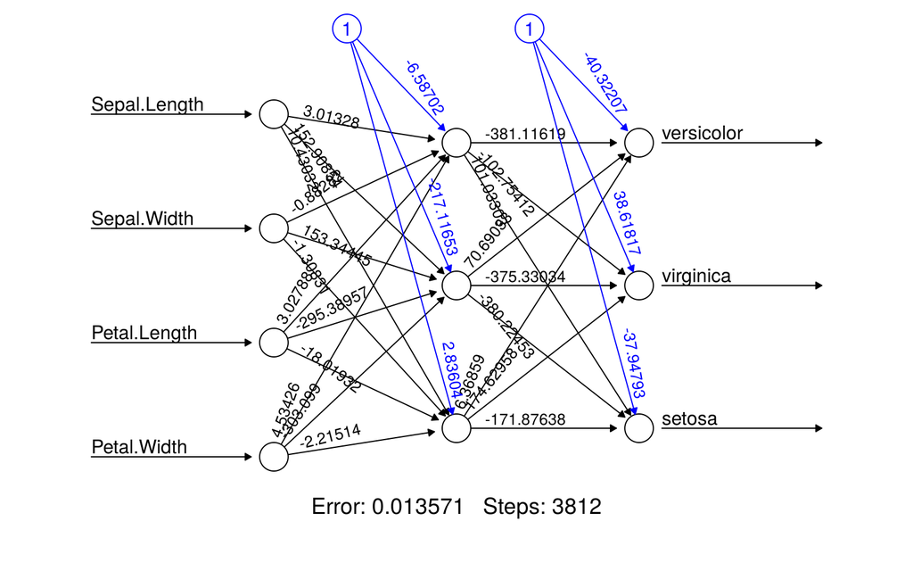

```r
plot(nn3, rep = "best")
```

## C3. How many hidden neurons?

```r
acc_nn <- function(hidden, seed) {
  set.seed(seed); idx <- sample(150, 105)
  m <- neuralnet(Species ~ ., sc[idx, ], hidden = hidden, linear.output = FALSE, stepmax = 1e5)
  mean(levels(sc$Species)[max.col(predict(m, sc[-idx, ]))] == sc$Species[-idx])
}
res <- expand.grid(hidden = c(1, 2, 3, 5), seed = 1:10)
res$acc <- mapply(acc_nn, res$hidden, res$seed)
aggregate(acc ~ hidden, res, function(a) round(c(mean = mean(a), min = min(a), max = max(a)), 3))
```

```
##   hidden acc.mean acc.min acc.max
## 1      1    0.904   0.600   0.978
## 2      2    0.931   0.889   0.956
## 3      3    0.931   0.911   0.956
## 4      5    0.929   0.822   0.956
```

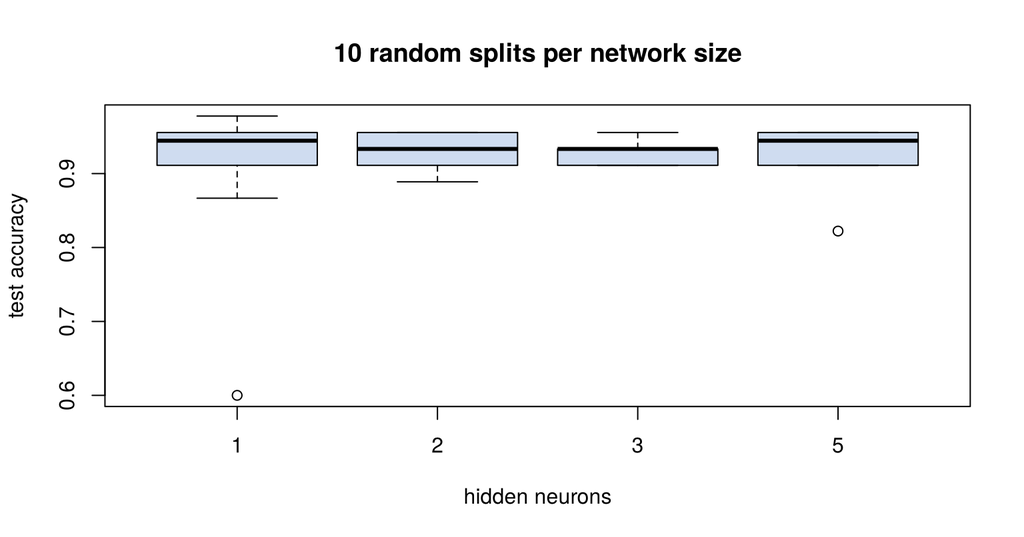

```r
boxplot(acc ~ hidden, res, xlab = "hidden neurons", ylab = "test accuracy", col = "#cfdcf0",
        main = "10 random splits per network size")
```

One hidden neuron is unreliable; two or three are consistently good. More neurons don’t help on this small problem and take longer to train.

## C4. Other parameters to explore (`?neuralnet`)

```r
set.seed(1)
two_layer <- neuralnet(Species ~ ., train, hidden = c(4, 2), linear.output = FALSE)  # two hidden layers
set.seed(1)
tanh_net  <- neuralnet(Species ~ ., train, hidden = 3, act.fct = "tanh", linear.output = FALSE)
set.seed(1)
backprop  <- neuralnet(Species ~ ., train, hidden = 3, algorithm = "backprop", learningrate = 0.01,
                       linear.output = FALSE, stepmax = 1e5)
acc <- function(m) mean(levels(sc$Species)[max.col(predict(m, test))] == test$Species)
sapply(list(two_layer = two_layer, tanh = tanh_net, backprop = backprop), function(m)
  c(test_accuracy = acc(m), steps = m$result.matrix["steps", 1]))
```

```
##                 two_layer         tanh     backprop
## test_accuracy   0.9333333    0.9333333 9.555556e-01
## steps.steps   428.0000000 2428.0000000 1.800300e+04
```

- `hidden = c(4, 2)`: two hidden layers of 4 and 2 neurons.
- `act.fct = "tanh"`: a different activation function (range −1 to 1).
- `algorithm = "backprop"` with a `learningrate`: classic gradient descent, usually far more steps than the default resilient backpropagation (`"rprop+"`).

## C5. Support vector machines

```r
for (k in c("linear", "polynomial", "radial")) {
  m <- svm(Species ~ ., data = train, kernel = k)
  cat(sprintf("%-10s test accuracy %.3f, support vectors %d\n", k, mean(predict(m, test) == test$Species), m$tot.nSV))
}
```

```
## linear     test accuracy 1.000, support vectors 23
## polynomial test accuracy 0.844, support vectors 48
## radial     test accuracy 0.978, support vectors 44
```

```r
tuned <- tune(svm, Species ~ ., data = train, ranges = list(cost = c(0.1, 1, 10), gamma = c(0.05, 0.25, 1)))
tuned$best.parameters
```

```
##   cost gamma
## 2    1  0.05
```

```r
mean(predict(tuned$best.model, test) == test$Species)
```

```
## [1] 0.9555556
```

## C6. Everything on the same split

```r
data.frame(method = c("k-NN (k = 5)", "decision tree", "SVM (radial)", "neural net (3)"),
  test_accuracy = c(mean(knn(train[, 1:4], test[, 1:4], train$Species, k = 5) == test$Species),
                    mean(predict(rpart(Species ~ ., train), test, type = "class") == test$Species),
                    mean(predict(svm(Species ~ ., train), test) == test$Species),
                    mean(pred3 == test$Species)))
```

```
##           method test_accuracy
## 1   k-NN (k = 5)     0.9333333
## 2  decision tree     0.9111111
## 3   SVM (radial)     0.9777778
## 4 neural net (3)     0.9555556
```

**Ask:** On iris every method scores above 90%. So how do you choose? By the other columns of the table in Part B: interpretability, data size, training and prediction time, and what the people using the model need.

# Summary

| Task | R |
| --- | --- |
| SQL in R | `con <- dbConnect(RSQLite::SQLite(), ":memory:")`, `dbWriteTable()`, `dbGetQuery(con, "SELECT ...")` |
| Validate | `ncol()`, `nrow()`, `sapply(df, range)`, `sum()`, `stopifnot()` |
| Joins | `merge(x, y, by.x, by.y, all.x / all.y / all)`, `inner_join()`, `left_join()`, `anti_join()` |
| Aggregate | `aggregate()`, `group_by() \|> summarise()` |
| Neural network | `neuralnet(y ~ ., data, hidden = 3, linear.output = FALSE)`, `predict()`, `plot(m, rep = "best")` |
| SVM | `svm(y ~ ., data, kernel = "radial")`, `tune(svm, ..., ranges = list(cost, gamma))` |